# Chapter 3: Bayesian Modelling

In the previous chapter, we explored Bayesian computation, focusing on both Markovian methods (such as Markov Chain Monte Carlo) and non-Markovian methods (such as variational inference). These approaches provided powerful tools to approximate posterior distributions when exact solutions are not feasible.

However, these methods raise an important question:

**What kind of models require such sophisticated computational techniques?**

This chapter addresses that question by focusing on Bayesian modelling, the process of constructing probabilistic representations of real-world phenomena.

In Bayesian modelling, we begin by specifying:

- A prior distribution to represent existing knowledge,
- A likelihood function to describe the data-generating process,
- And observed data,

which together define the posterior distribution—the central object computed using the methods introduced earlier.

The distinction between Markovian and non-Markovian computation also reflects the complexity of the models we build. Simple models may allow direct or efficient sampling, while more complex models such as those with high-dimensional parameters or latent structures—require advanced computational strategies.

A key feature of Bayesian modelling is that uncertainty is explicitly modelled. Parameters are treated as random variables, and this allows us to move beyond point estimates toward full probabilistic inference.

In this chapter, we will develop a range of Bayesian models, starting from simple and interpretable structures and gradually moving toward more flexible and expressive frameworks. These include:

- Linear models, forming the foundation of many statistical methods,
- Mixture models, which capture hidden subpopulations,
- Latent variable models such as topic models,
- State space models, for sequential and time-dependent data,
- Gaussian processes, enabling non-parametric modelling,
- And smoothing with basis expansions, linking Bayesian ideas with functional approximation.

The emphasis will be on understanding how to formulate models, interpret their components, and connect them to real-world problems, while leveraging the computational tools developed in the previous chapter.

## Bayesian Linear Models

We begin our study of Bayesian modelling with one of the most fundamental and widely used model classes: linear models.

At its core, a linear model assumes a simple but powerful idea:

**The response variable can be expressed as a linear combination of input variables, plus some uncertainty.**

In a classical setting, linear regression focuses on estimating fixed coefficients that best explain the relationship between predictors and the response. However, this approach provides only a single “best” estimate and does not fully capture uncertainty in the model parameters.

The Bayesian perspective takes this a step further by treating these coefficients as random variables. Instead of estimating a single value, we assign:

- Prior distributions to the coefficients, representing our initial beliefs,
- A likelihood function based on the assumed data-generating process (often Gaussian noise),

and then combine them to obtain a posterior distribution over the coefficients.

This shift has important consequences:

- We obtain a **distribution of plausible parameter values**, not just point estimates,
- We can quantify uncertainty in predictions,
- And we can naturally incorporate prior knowledge into the model.

Bayesian linear models also serve as a foundation for many more advanced models. Concepts introduced here, such as prior specification, likelihood construction, and posterior inference, extend directly to more complex settings like hierarchical models, Gaussian processes, and neural networks.

Many problems in science, engineering, business, and artificial intelligence involve understanding relationships between variables.

In these problems, we typically define:

- A **dependent variable (target/output)**: the variable we want to predict (usually continuous)
- One or more **independent variables (inputs/features)**: variables used to explain or predict the target

The relationship between inputs and output can be written as:

$$y=f(x_1,x_2, \dots ,x_p) + \epsilon$$

where:

- $y$: dependent (target) variable
- $x_1,x_2, \dots ,x_p$: independent variables (inputs/features)
- $f(⋅)$: unknown function that represents the true relationship between inputs and output
- $\epsilon$: noise or random error (unexplained variation)

**What is $f$?**

The function $f$ represents the **true underlying relationship** between input variables and the output.

- It is generally unknown
- It is what we are trying to learn from data
- It may be linear or highly nonlinear in reality

In machine learning terms $f$ is the true data-generating process, which we attempt to approximate using a model.

Different modelling approaches correspond to different assumptions about $f$.

#### Linear Model Assumption

In linear regression, we assume that $f$ can be approximated by a linear function:

$$f(x_1,x_2, \dots ,x_p) = \omega_0 + \omega_1x_1 + \omega_2x_2 + \dots+\omega_px_p $$

Therefore, the model becomes:

$$y = \omega_0 + \omega_1x_1 + \omega_2x_2 + \dots+\omega_px_p +\epsilon$$

where:

- $\omega_0$: intercept (bias term)
- $\omega_1 , \omega_2, \dots, \omega_p$: model parameters (weights)

### Simple linear regression

Now that we have discussed the general ideas behind linear regression, we now focus on how to formally build linear models.

A familiar starting point is the simple linear regression equation:

$$y_i = \alpha+ \beta x_i +\epsilon_i$$

This equation describes a linear relationship (straight-light relationship) between the input variable $x_i$ and the output variable $y_i$.

**Interpretation of Parameters**

- $\alpha$ (Intercept): The value of $y_i$ when $x_i=0$. Graphically, it is the point where the regression line intersects the y-axis.
- $\beta$ (Slope): Controls the rate of change of $y_i$ with respect to $x_i$. It represents the change in $y_i$ for a one-unit change in $x_i$
- $\epsilon_i$ (Error term): Represents random noise or unexplained variation in the data.

**Least Squares Estimation**

There are several methods to estimate the parameters α and β. One of the most common approaches is least squares fitting.

In practice, when fitting a regression line using software, this method is typically used internally.

The idea is to find parameter values that minimize the squared differences between observed and predicted values:

$$\min_{\alpha,\beta} \sum_{i=1}^{n} \left( y_i - \hat{y}_i \right)^2$$

Where

$$\hat{y}_i = \hat{\alpha} + \hat{\beta} x_i$$

This formulation turns regression into an optimization problem, where we minimize a loss function.

**Probabilistic Interpretation**

Linear regression can also be expressed in a probabilistic framework.

Instead of modeling a deterministic line with noise, we assume that the output is generated from a probability distribution:

$$y_i \sim \mathcal{N}(\mu_i, \sigma^2)$$

where the mean is given by:

$$\mu_i=\alpha+\beta x_i$$

Therefore, the full model becomes:

$$y_i \sim \mathcal{N}(\alpha+\beta x_i, \sigma^2)$$

It is important to distinguish:

- $\epsilon_i$: individual random noise term (a random variable)
- $\sigma^2$: variance of the noise distribution

We Define $$\epsilon_i \sim \mathcal{N}(0, \sigma^2)$$

and therefore:

$$y_i=\alpha+\beta x_i+\epsilon_i$$

is equivalent to the probabilistic form above.

**Bayesian Formulation**

**Choice of Priors**

In a Bayesian framework, we treat the parameters as random variables and assign prior distributions:

$$\alpha \sim \mathcal{N}(\mu_{\alpha}, \sigma_{\alpha}^2)$$

$$\beta \sim \mathcal{N}(\mu_{\beta}, \sigma_{\beta}^2)$$

$$\sigma \sim \text{HalfNormal}(s) \quad \text{or} \quad \sigma \sim \text{HalfCauchy}(s) $$

- Intercept ($\alpha$): Typically assigned a weakly informative (wide) Gaussian prior because its scale varies across problems.
- Slope ($\beta$): Also often given a weak Gaussian prior. In some cases, domain knowledge may inform its sign or range.
- Noise ($\sigma$): Must be positive, so distributions like Half-Normal or Half-Cauchy are commonly used. These act as regularizing priors.

If strong prior knowledge exists about variability, a Gamma distribution can also be used.

**Connection to Least Squares**

- When the priors are very weak (i.e., highly non-informative), the Bayesian solution converges closely to the least squares solution.

Thus:

- Least squares → point estimate
- Bayesian regression → full uncertainty-aware distribution

Now we need data to update these priors and learn the posterior distribution from observations.

To build intuition, we will use a synthetic dataset. Using synthetic data is helpful because we already know the true parameter values, allowing us to evaluate how well the model recovers them.

The following code generates data from a simple linear relationship with Gaussian noise:

```python
import numpy as np
import matplotlib.pyplot as plt
import seaborn as sns

np.random.seed(314)

N = 100

alpha_real = 2.5
beta_real = 0.9

sigma_real = 0.5

x = np.random.normal(10, 1, size=N)

y_real = alpha_real + beta_real * x

y = np.random.normal(y_real, sigma_real)
```

Here:

- `alpha_real` is the true intercept
- `beta_real` is the true slope
- `sigma_real` controls the amount of noise
- `y_real` represents the true regression line
- `y` represents the observed noisy data

The following code visualizes the data:

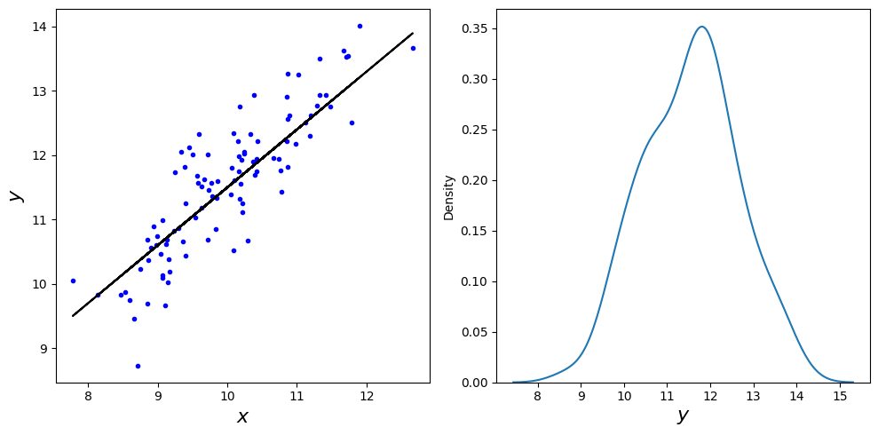

```python
plt.figure(figsize=(10, 5))

plt.subplot(1, 2, 1)

plt.plot(x, y, 'b.')
plt.plot(x, y_real, 'k')

plt.xlabel('$x$', fontsize=16)
plt.ylabel('$y$', fontsize=16)

plt.subplot(1, 2, 2)

sns.kdeplot(y)

plt.xlabel('$y$', fontsize=16)

plt.tight_layout()
```

The left plot shows the observed data together with the true regression line. The right plot shows the distribution of the response variable.

## Fitting the Bayesian Linear Regression Model

We now use PyMC to fit the Bayesian linear regression model.

```python
import pymc as pm
import arviz as az

with pm.Model() as model:

    alpha = pm.Normal(
        "alpha",
        mu=0,
        sigma=10 # weakly informative prior.
    )

    beta = pm.Normal(
        "beta",
        mu=0,
        sigma=1
    )

    sigma = pm.HalfCauchy(
        "sigma",
        beta=5
    )

    mu = pm.Deterministic(
        "mu",
        alpha + beta * x
    )

    y_obs = pm.Normal(
        "y_obs",
        mu=mu,
        sigma=sigma,
        observed=y
    )

    step = pm.Metropolis()

    trace = pm.sample(
        draws=10000,
        step=step,
        random_seed=314,
        return_inferencedata=True
    )
```

[output not shown]

```
Sampling 4 chains for 1_000 tune and 10_000 draw iterations (4_000 + 40_000 draws total) took 539 seconds.
The rhat statistic is larger than 1.01 for some parameters. This indicates problems during sampling. See https://arxiv.org/abs/1903.08008 for details
The effective sample size per chain is smaller than 100 for some parameters.  A higher number is needed for reliable rhat and ess computation. See https://arxiv.org/abs/1903.08008 for details
```

### Deterministic Variables

The variable mu is defined as a deterministic variable:

mu = pm.Deterministic( "mu", alpha + beta * x )

Unlike stochastic variables, deterministic variables do not generate random values directly. Their values are completely determined by other variables in the model.

In this example:

- `alpha` and `beta` are stochastic variables
- `x` is observed data
- `mu` is computed directly from them

Mathematically: $$\mu_i = \alpha + \beta x_i$$

Therefore, once values for alpha and beta are known, the value of mu is fully determined.

Even though mu is not sampled independently, PyMC stores it in the trace when we explicitly define it using `pm.Deterministic()`. This is useful because mu represents the fitted mean response of the model for every observation.

Saving mu allows us to:

- visualize the fitted regression line
- compute credible intervals
- analyze posterior predictions
- study uncertainty in the estimated relationship

Without explicitly storing mu, we would need to recompute it manually from posterior samples of alpha and beta.

**Trace Plots**

We can inspect the sampling behavior using trace plots:

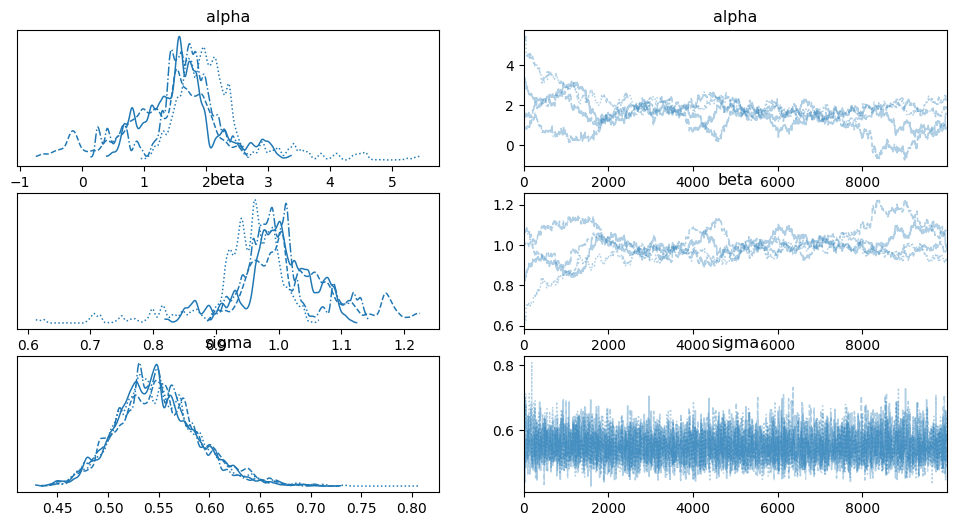

```python
az.plot_trace(
    trace,
    var_names=["alpha", "beta", "sigma"]
);
```

The traceplots show different behaviors across the parameters, indicating varying levels of sampling efficiency.

In contrast, the trace for σ (sigma) shows much better behavior. All four chains quickly converge to a similar region and mix well, indicating stable and efficient sampling for this parameter.

Overall, the traceplots suggest that while σ is well-estimated, the sampling for α and β is inefficient, with slow mixing and sensitivity to initial values, which is typical under Metropolis–Hastings for correlated parameters in linear regression models

**Autocorrelation in Linear Models**

Autocorrelation plots provide additional insight into sampling efficiency:

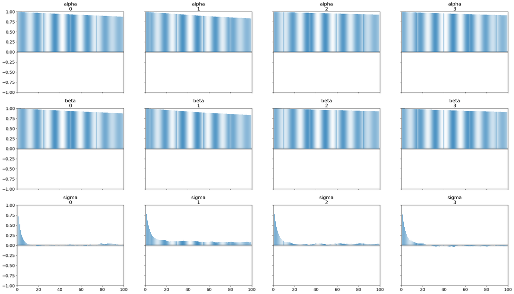

```python
var_names = ["alpha", "beta", "sigma"]

az.plot_autocorr(
    trace,
    var_names=var_names,
    grid=(3, 4)
);
```

The autocorrelation plots show a strong dependence between successive samples for α (alpha) and β (beta), indicating high autocorrelation. In contrast, σ (sigma) shows much lower autocorrelation, suggesting better mixing and more efficient sampling for this parameter.

This behavior is typical in linear regression models, where the intercept and slope are strongly correlated in the posterior distribution, making them harder to explore efficiently using simple sampling methods

```python
az.summary(
    trace,
    var_names=["alpha", "beta", "sigma"],
    round_to=3 # Round all numerical values in the summary output to 3 decimal places
)
```

|  | mean | sd | hdi_3% | hdi_97% | mcse_mean | mcse_sd | ess_bulk | ess_tail | r_hat |
| --- | --- | --- | --- | --- | --- | --- | --- | --- | --- |
| alpha | 1.647 | 0.703 | 0.190 | 2.934 | 0.204 | 0.140 | 12.099 | 23.036 | 1.255 |
| beta | 0.992 | 0.070 | 0.858 | 1.132 | 0.020 | 0.014 | 12.101 | 23.431 | 1.255 |
| sigma | 0.549 | 0.041 | 0.474 | 0.626 | 0.001 | 0.001 | 1985.323 | 3170.681 | 1.004 |

**Overall Model and Sampling Diagnosis**

- The Metropolis-Hastings sampler shows poor convergence behavior for the regression model.
- This is clearly indicated by the R-hat value of 1.255 for both alpha and beta, which is significantly above the acceptable threshold of 1.01.
- An R-hat value this large suggests that different chains are not agreeing with each other, meaning the Markov chains have not fully converged to the same posterior distribution.
- As a result, the posterior estimates for alpha and beta should be treated with caution.

**Interpretation of Intercept (alpha)**

- The posterior mean of alpha is approximately 1.65, representing the estimated intercept of the regression line.
- The HDI (94% credible interval) is [0.19, 2.93], which is relatively wide.
- This wide interval indicates substantial uncertainty in the intercept estimate.
- The effective sample size (ESS ≈ 12) is extremely low, meaning the sampler is producing highly correlated samples.
- The high Monte Carlo standard error (MCSE ≈ 0.204) further indicates that the estimate is unstable.
- Overall, the intercept is poorly estimated due to inefficient sampling and strong parameter dependence.

**Interpretation of Slope (beta)**

- The posterior mean of beta is approximately 0.99, suggesting a strong positive linear relationship between x and y.
- The HDI [0.858, 1.132] is relatively narrow compared to alpha, indicating that the data provides stronger information about the slope.
- However, despite the seemingly reasonable estimate, the ESS is still extremely low (~12).
- The R-hat value of 1.255 confirms lack of convergence, meaning different chains are producing inconsistent slope estimates.
- Therefore, although the slope value is intuitively correct, it is not statistically reliable under this sampler.

**Interpretation of Noise Parameter (sigma)**

- The posterior mean of sigma is approximately 0.549, which represents the standard deviation of observation noise.
- The HDI [0.474, 0.626] is narrow and well-defined.
- Unlike alpha and beta, the ESS is high (~1985), indicating good sampling efficiency.
- The R-hat value (~1.004) is close to 1, confirming good convergence for this parameter.
- This shows that sigma is not strongly affected by the correlation issues present in the regression coefficients.

**Sampling Efficiency and Diagnostic Interpretation**

- The extremely low ESS for alpha and beta indicates that successive samples are highly correlated, meaning the sampler is not exploring the posterior efficiently.
- The high MCSE values for these parameters show that numerical uncertainty in the estimates is large relative to their variability.
- In contrast, sigma shows high ESS and low MCSE, confirming that it is well-explored by the sampler.
- This mismatch highlights that different parameters can have very different sampling difficulty within the same model.

### Why Metropolis–Hastings fails in linear regression

The core problem is not the model, but the shape of the posterior distribution.

**Geometric interpretation of the problem**

The key reason is the structure of the linear regression model itself:

$$y_i = \alpha+ \beta x_i +\epsilon_i$$

In linear regression, many different combinations of alpha (intercept) and beta (slope) can produce nearly identical fitted lines.

This happens because:

- increasing the slope can be compensated by decreasing the intercept
- decreasing the slope can be compensated by increasing the intercept

So the parameters are not independent — they are tightly linked by the data fit constraint.

**Intuition: the “pivot point” effect**

A useful way to understand this is to imagine the regression line:

-All reasonable regression lines tend to pass near the “center” of the data

- This center is approximately the mean of x and y
- So the fitting process behaves like a line rotating around a central region of the data

If the slope increases:

- the line tilts upward
- but to maintain a good fit, the intercept must decrease

If the slope decreases:

- the line flattens
- and the intercept must increase

This creates a strong dependency between parameters, meaning they move together during sampling.

**Posterior structure**

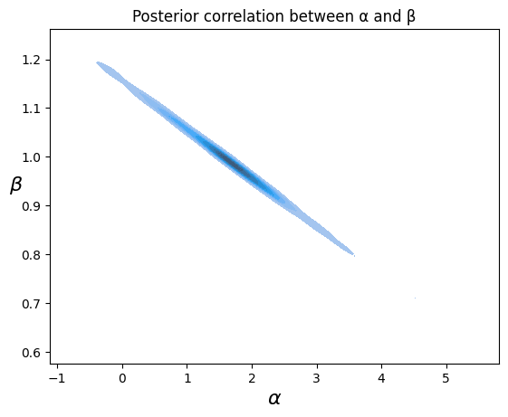

```python
alpha_samples = trace.posterior["alpha"].values.flatten()
beta_samples  = trace.posterior["beta"].values.flatten()

sns.kdeplot(
    x=alpha_samples,
    y=beta_samples,
    fill=True
)

plt.xlabel(r'$\alpha$', fontsize=16)
plt.ylabel(r'$\beta$', fontsize=16, rotation=0)
plt.title("Posterior correlation between α and β")
plt.show()
```

When we visualize the joint posterior distribution of alpha and beta, we can observe a long, narrow, diagonal-shaped region of high probability rather than a circular cloud. This indicates strong posterior correlation. This diagonal structure is the key reason for sampling difficulty.

**Why Metropolis–Hastings struggles**

Metropolis–Hastings (MH) is a random-walk based sampling method. At each iteration, it proposes a small random move in any direction of the parameter space and then accepts or rejects this move based on the posterior probability. However, the key limitation of MH is that it does not have any knowledge of the geometric structure of the posterior distribution.

In linear regression, the posterior distribution of the parameters does not form a simple circular shape. Instead, it forms a narrow diagonal ridge due to the strong dependence between the intercept (α) and slope (β). As a result, valid parameter values lie along a slanted path rather than being evenly spread in all directions. Because MH proposes moves randomly in all directions, it does not align with this structure and therefore frequently proposes points outside the high-probability region.

**What actually happens during sampling**

When the Metropolis–Hastings algorithm proposes large jumps in parameter space, these jumps often land outside the narrow ridge of high probability. Since these regions correspond to poor model fits, such proposals are rejected. This leads to a high rejection rate and inefficient exploration of the posterior distribution.

On the other hand, when MH uses small random steps, the proposals are more likely to remain within the valid ridge. However, progress becomes extremely slow because the chain can only move through many small incremental steps. As a result, the sampler explores the posterior in a slow and inefficient zig-zag pattern.

**Analogy**

This behavior can be understood using the analogy of walking through a narrow mountain corridor while blindfolded. Imagine that the valid region of the posterior is a long, narrow path in a mountainous area. The goal is to travel from one end of the path to the other.

Since the Metropolis–Hastings algorithm does not know the direction of the path, it takes random steps in all directions. Sometimes it tries to step into the mountain walls, which corresponds to low-probability regions and results in rejection. At other times, it takes small safe steps along the corridor, but progress is very slow.

Therefore, the movement becomes inefficient, the sampler often gets stuck in local regions, and it repeatedly revisits similar states instead of efficiently exploring the full posterior.

Because the movement of the sampler is slow and constrained, successive samples tend to be very similar to each other. Each new sample depends heavily on the previous one, as the chain can only move gradually along the narrow ridge.

This leads to high autocorrelation between samples, meaning that the samples are not independent. As a result, the effective sample size becomes very low even if a large number of iterations are performed. This reduces the efficiency and reliability of the inference.

### Changing the Sampling Method

One way to reduce the autocorrelation problem is to use a more advanced sampling algorithm.

The Metropolis-Hastings algorithm struggles when the posterior distribution has a narrow diagonal geometry, as in Bayesian linear regression. In such cases, the sampler moves slowly because it proposes random local steps without considering the shape of the posterior distribution.

A more efficient alternative is the No-U-Turn Sampler (NUTS).

NUTS is an adaptive version of Hamiltonian Monte Carlo (HMC). Unlike Metropolis-Hastings, NUTS uses gradient information from the posterior distribution to guide the sampling process.

As a result:

NUTS can move efficiently along narrow diagonal regions autocorrelation is significantly reduced mixing improves fewer samples are needed to approximate the posterior accurately

Although each NUTS iteration is computationally more expensive, the overall sampling process is usually much more efficient.

Bayesian Linear Regression using NUTS

The following model is identical to the previous regression model, except that we now use the NUTS sampler.

```python
import pymc as pm
import arviz as az
import numpy as np

with pm.Model() as model_n:

    alpha = pm.Normal(
        "alpha",
        mu=0,
        sigma=10
    )

    beta = pm.Normal(
        "beta",
        mu=0,
        sigma=1
    )

    sigma = pm.HalfCauchy(
        "sigma",
        beta=5
    )

    mu = pm.Deterministic(
        "mu",
        alpha + beta * x
    )

    y_obs = pm.Normal(
        "y_obs",
        mu=mu,
        sigma=sigma,
        observed=y
    )

    # Bayesian R-squared type measure
    rb = pm.Deterministic(
        "rb",
        (beta * x.std() / y.std()) ** 2
    )

    y_mean = y.mean()

    ss_reg = pm.math.sum((mu - y_mean) ** 2)

    ss_tot = pm.math.sum((y - y_mean) ** 2)

    rss = pm.Deterministic(
        "rss",
        ss_reg / ss_tot
    )

    step = pm.NUTS()

    trace_n = pm.sample(
        draws=2000,
        tune=1000,
        step=step,
        random_seed=314,
        return_inferencedata=True
    )
```

```
Multiprocess sampling (4 chains in 4 jobs)
NUTS: [alpha, beta, sigma]
```

```
Sampling 4 chains for 1_000 tune and 2_000 draw iterations (4_000 + 8_000 draws total) took 2488 seconds.
```

A tuning phase of 1000 iterations is included to allow NUTS to adapt its sampling behavior before collecting posterior samples, leading to improved convergence and more efficient exploration of the posterior distribution

**Trace Plots**

We can inspect the sampling behavior using trace plots:

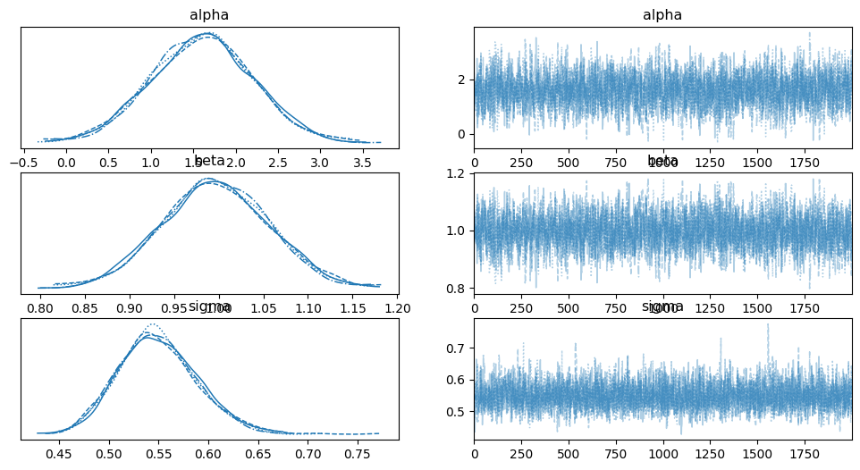

```python
az.plot_trace(
    trace_n,
    var_names=["alpha", "beta", "sigma"]
);
```

Compared to the Metropolis–Hastings sampler, the NUTS traces for α, β, and σ show substantially improved sampling behavior. The chains fluctuate more rapidly and overlap closely with each other, indicating efficient mixing and faster exploration of the posterior distribution. The long slow drifts previously observed for α and β are largely eliminated, while the already stable behavior of σ is further improved.

This overall behavior indicates lower autocorrelation, better convergence across chains, and significantly higher sampling efficiency for all three parameters.

**Autocorrelation Plots**

We can further evaluate sampling efficiency using autocorrelation plots:

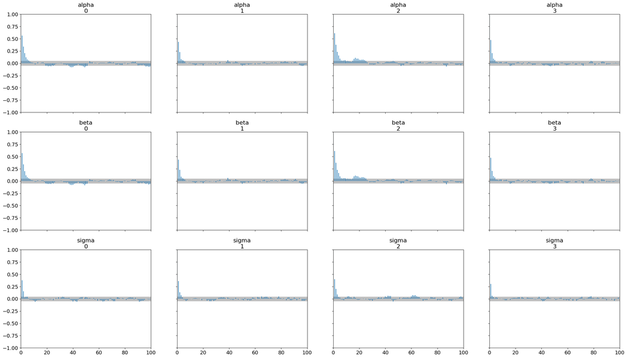

```python
az.plot_autocorr(
    trace_n,
    var_names=["alpha", "beta", "sigma"],
    grid=(3, 4)
);
```

Compared to Metropolis–Hastings, the autocorrelation for α, β, and σ decreases much more rapidly under NUTS. Successive samples become approximately independent more quickly, leading to substantially larger effective sample sizes for all parameters.

This indicates that fewer samples are needed to accurately approximate the posterior distribution, resulting in more reliable parameter estimates and improved computational efficiency.

The improvement occurs because the default sampler follows the geometry of the posterior distribution rather than performing purely random local moves.

In diagonal posterior regions, the sampler can efficiently travel along the high-probability ridge, whereas Metropolis-Hastings tends to move slowly and inefficiently.

The choice of sampling algorithm strongly affects Bayesian inference performance.

For correlated posterior distributions:

- simple random-walk methods often produce slow mixing
- gradient-based methods dramatically improve efficiency

Modern Bayesian frameworks therefore use advanced samplers by default for continuous probabilistic models.

```python
az.summary(
    trace_n,
    var_names=["alpha", "beta", "sigma"],
    round_to=3 # Round all numerical values in the summary output to 3 decimal places
)
```

|  | mean | sd | hdi_3% | hdi_97% | mcse_mean | mcse_sd | ess_bulk | ess_tail | r_hat |
| --- | --- | --- | --- | --- | --- | --- | --- | --- | --- |
| alpha | 1.601 | 0.60 | 0.524 | 2.780 | 0.013 | 0.009 | 2230.927 | 2246.969 | 1.001 |
| beta | 0.997 | 0.06 | 0.878 | 1.103 | 0.001 | 0.001 | 2223.780 | 2098.092 | 1.001 |
| sigma | 0.549 | 0.04 | 0.478 | 0.624 | 0.001 | 0.001 | 3658.222 | 3518.450 | 1.002 |

**Overall Model and Sampling Diagnosis**

- The NUTS sampler shows excellent convergence behavior for the regression model.
- This is clearly indicated by the R-hat values close to 1 (1.001–1.002) for all parameters, which is well within the acceptable threshold of 1.01.
- Such R-hat values confirm that all chains agree and have converged to the same posterior distribution.
- The very high effective sample sizes (ESS) indicate efficient exploration of the posterior with low autocorrelation.
- As a result, the posterior estimates for all parameters are reliable and stable

**Interpretation of Intercept (alpha)**

- The posterior mean of beta is approximately 0.997, while the true value is 0.9, showing very accurate recovery of the slope.
- The HDI [0.878, 1.103] is narrow and includes the true value, indicating strong parameter identifiability.
- The standard deviation (0.06) is small, showing high precision in the estimate.
- The ESS (≈ 2224) is high, confirming efficient sampling.
- The R-hat value (1.001) indicates perfect convergence behavior.
- Overall, the slope is accurately and reliably estimated, confirming the correctness of the linear relationship.

**Interpretation of Noise Parameter (sigma)**

- The posterior mean of sigma is approximately 0.549, while the true value is 0.5, showing close agreement.
- The HDI [0.478, 0.624] includes the true value, indicating correct uncertainty quantification.
- The standard deviation (0.04) is small, showing precise estimation of noise.
- The ESS (≈ 3658) is very high, indicating excellent sampling efficiency.
- The R-hat value (1.002) confirms stable and well-converged sampling.
- Overall, the noise level is accurately identified and well learned from the data.

**Sampling Efficiency and Diagnostic Interpretation**

- All parameters show high effective sample sizes, indicating low autocorrelation and efficient exploration of the posterior space.
- MCSE values are very small, showing that numerical estimation error is negligible.
- All R-hat values are close to 1, confirming strong convergence across chains.
- Unlike Metropolis-Hastings, there is no evidence of sampling inefficiency or poor mixing.
- This demonstrates that NUTS successfully handles the correlated structure between alpha and beta.
- The model successfully recovers all true parameters within posterior uncertainty.
- NUTS provides stable, accurate, and efficient Bayesian inference.
- Compared to Metropolis-Hastings, NUTS eliminates issues of poor mixing, high autocorrelation, and convergence failure by adapting to the geometry of the posterior distribution.

The estimate of the intercept (α ≈ 1.6) is not very close to the true value (α = 2.5), but this discrepancy is not mainly due to the prior choice. Instead, it arises because α and β are strongly negatively correlated in the posterior distribution, meaning that changes in the slope are compensated by changes in the intercept. In addition, since the predictor variable x is not centered around zero (it is centered around 10), the intercept becomes harder to identify directly and is more sensitive to this trade-off, leading to a less accurate estimate compared to the slope and noise parameters.

NUTS performs better because it uses gradient information to understand the shape of the posterior distribution and then moves in directions that follow high-probability regions efficiently.

A useful analogy is to imagine exploring a long, narrow mountain valley in fog. In NUTS, the sampler works on the negative log-posterior (energy function), where high-probability regions correspond to low-energy areas. This transformation allows the posterior to be interpreted geometrically as a valley, where efficient sampling corresponds to moving along the bottom of this high-density region rather than exploring low-probability areas.

In NUTS, instead of randomly stepping in any direction, NUTS can “feel” the slope of the ground and automatically choose directions that keep it within the valley while moving forward. This prevents it from repeatedly hitting the steep walls and wasting time.

As a result, it explores the entire valley smoothly and quickly, collecting more independent samples in fewer steps.

### Interpreting and Visualizing the Posterior

Once we have obtained the posterior distribution, we can explore and interpret it using summary tools such as trace plots, summary tables, or custom visualizations. For linear regression models, a particularly useful approach is to visualize the fitted regression line using posterior mean estimates of the parameters.

**Posterior Mean Regression Line**

We first compute the posterior mean of the parameters and plot the best-fitting line:

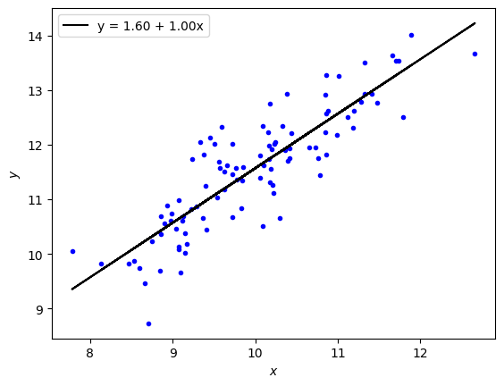

```python
plt.plot(x, y, 'b.')

alpha_m = trace_n.posterior["alpha"].mean().item()
beta_m = trace_n.posterior["beta"].mean().item()

plt.plot(
    x,
    alpha_m + beta_m * x,
    c='k',
    label=f"y = {alpha_m:.2f} + {beta_m:.2f}x"
)

plt.xlabel("$x$")
plt.ylabel("$y$")
plt.legend()
```

- This black line represents the average regression line under the posterior.
- It is the best single summary of the model.
- However, it does not show uncertainty, only central tendency.

**Visualizing Posterior Uncertainty (Sampled Lines)**

To understand uncertainty in the regression, we plot multiple regression lines sampled from the posterior:

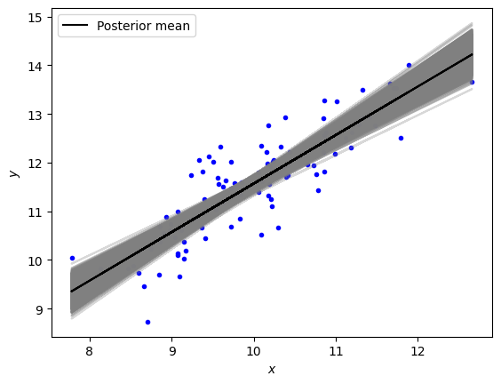

```python
plt.plot(x, y, 'b.')

alpha_samples = trace_n.posterior["alpha"].stack(samples=("chain", "draw")).values
beta_samples  = trace_n.posterior["beta"].stack(samples=("chain", "draw")).values

idx = np.random.choice(alpha_samples.shape[0], 100, replace=False)

for a, b in zip(alpha_samples, beta_samples):
    plt.plot(x, a + b * x, color='gray', alpha=0.3)

plt.plot(
    x,
    alpha_m + beta_m * x,
    c='k',
    label="Posterior mean"
)

plt.xlabel("$x$")
plt.ylabel("$y$")
plt.legend()
```

- Each gray line represents a plausible regression line from the posterior.
- The spread between lines shows uncertainty in the model.
- Uncertainty is smaller near the center of the data and larger at the edges.
- This reflects that predictions are more confident where data is dense.

**Credible Interval for the Mean Function (HPD band)**

Instead of plotting many lines, we can summarize uncertainty using a credible band for the mean prediction:

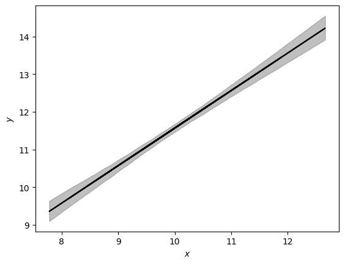

```python
mu_samples = trace_n.posterior["mu"].values

# compute HDI (this is already per x-point)
hdi_mu = az.hdi(mu_samples, hdi_prob=0.94)

# sort x for smooth plotting
idx = np.argsort(x)
x_ord = x[idx]

# reorder HDI according to sorted x
hdi_mu_ord = hdi_mu[idx]

# posterior mean line
plt.plot(x, alpha_m + beta_m * x, c='k')

# uncertainty band
plt.fill_between(
    x_ord,
    hdi_mu_ord[:, 0],
    hdi_mu_ord[:, 1],
    color='gray',
    alpha=0.5
)

plt.xlabel("$x$")
plt.ylabel("$y$")
```

**Posterior Predictive Uncertainty (ŷ: Future Observations)**

One more option is to plot the HPD intervals for the predicted data $\hat{y}$, that is, the values of future observations generated from the model.

This represents the question: *Where do we expect to see future data points, given the learned model?*

Unlike the previous plot (which shows uncertainty in the mean function μ), this plot includes both parameter uncertainty and observation noise, making it more realistic for prediction.

**Key Difference from Mean Function HPD**

The main difference is that the mean function HPD (μ-band) only reflects uncertainty in the estimated regression line, while the predictive HPD (ŷ-band) reflects the total uncertainty in future observations. Therefore, the predictive band is always wider because it includes both uncertainty in the model parameters and the natural variability (noise) in the data.

We summarize this predictive uncertainty using HPD intervals:

- The 95% HPD interval shows where most future observations are expected to fall.
- The 50% HPD interval shows the most likely region of future outcomes.
- A lighter gray band is used for 95% uncertainty, and a darker gray band is used for 50% uncertainty.

```python
with model_n:
    ppc = pm.sample_posterior_predictive(trace_n)
```

```
Sampling: [y_obs]
```

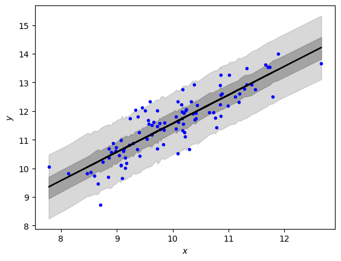

```python
# posterior predictive samples
y_pred_samples = ppc.posterior_predictive["y_obs"].values

# sort x for smooth plotting
idx = np.argsort(x)
x_ord = x[idx]

# HDI intervals (95% and 50%)
hdi_95 = az.hdi(y_pred_samples, hdi_prob=0.95)
hdi_50 = az.hdi(y_pred_samples, hdi_prob=0.50)

# reorder to match sorted x
hdi_95 = hdi_95[idx]
hdi_50 = hdi_50[idx]

# plot observed data
plt.plot(x, y, "b.")

# posterior mean line
alpha_m = trace_n.posterior["alpha"].mean().item()
beta_m = trace_n.posterior["beta"].mean().item()

plt.plot(
    x,
    alpha_m + beta_m * x,
    "k"
)

# 95% predictive interval (light gray)
plt.fill_between(
    x_ord,
    hdi_95[:, 0],
    hdi_95[:, 1],
    color="gray",
    alpha=0.3
)

# 50% predictive interval (darker gray)
plt.fill_between(
    x_ord,
    hdi_50[:, 0],
    hdi_50[:, 1],
    color="gray",
    alpha=0.6
)

plt.xlabel("$x$")
plt.ylabel("$y$")
plt.show()
```

- This plot shows uncertainty in future observations $\hat{y}$, not just the mean relationship.
- The black line represents the posterior mean regression function.
- The 50% HPD band shows where future observations are most likely to occur.
- The 95% HPD band captures the broader range of possible future outcomes.
- These bands are wider than the mean-function HPD because they include both parameter uncertainty and observation noise.
- This makes the plot directly useful for forecasting and prediction uncertainty analysis

In the Metropolis–Hastings (MH) model, we requested 10,000 samples because the sampler produced highly autocorrelated chains, especially for α and β. Since successive samples were very similar to one another, many samples carried redundant information. As a result, the effective sample size remained very low despite generating a large number of draws.

In contrast, NUTS produced much lower autocorrelation and explored the posterior distribution far more efficiently. Even with only 2,000 samples, the chains mixed well and generated many more effectively independent samples.